# Árboles de regresión

Javier Cara

```r
library(tree)
datos = read.table('coches.txt',header=T)
```

```r
t1 = tree(consumo ~ cv + peso,data=datos)
```

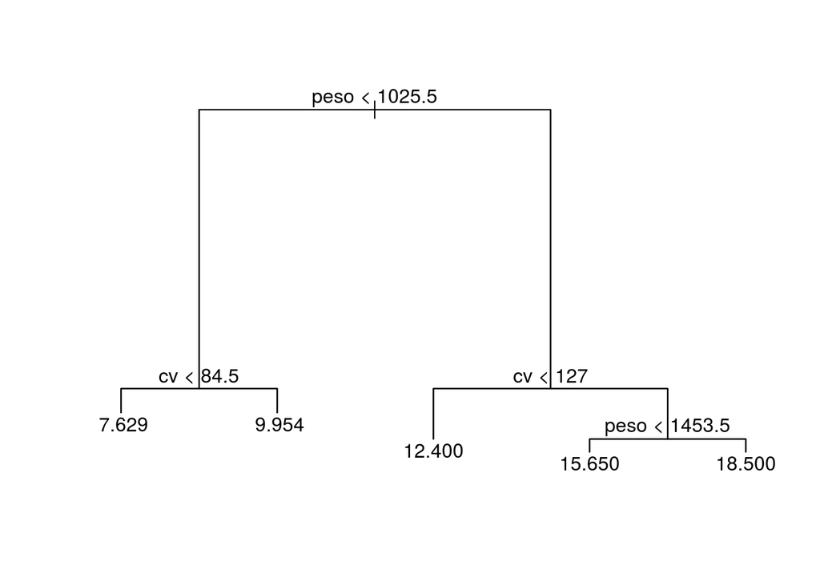

```r
plot(t1)
text(t1, pretty=0)
```

vemos que los dos regresores son influyentes en el consumo, ya que se han empleado en las particiones.

```r
print(t1)
```

```
## node), split, n, deviance, yval
##       * denotes terminal node
##
##  1) root 391 5911.0 11.230
##    2) peso < 1025.5 232  839.7  8.711
##      4) cv < 84.5 124  212.9  7.629 *
##      5) cv > 84.5 108  314.8  9.954 *
##    3) peso > 1025.5 159 1458.0 14.900
##      6) cv < 127 63  235.1 12.400 *
##      7) cv > 127 96  569.8 16.540
##       14) peso < 1453.5 66  243.0 15.650 *
##       15) peso > 1453.5 30  159.5 18.500 *
```

Lo que devuelve la tabla es:

- Numero del nodo
- split: criterio para hacer la partición del nodo
- n: numero de datos que componen el nodo.
- deviance: = RSS = $\sum(y_i - \hat{y}_i)^2$.

```r
n = nrow(datos)
( deviance_root = sum( (datos$consumo - mean(datos$consumo))^2 ) )
```

```
## [1] 5910.742
```

- yval: predicción del nodo = $\bar{y}$

```r
mean(datos$consumo)
```

```
## [1] 11.22762
```

## Parámetros del árbol

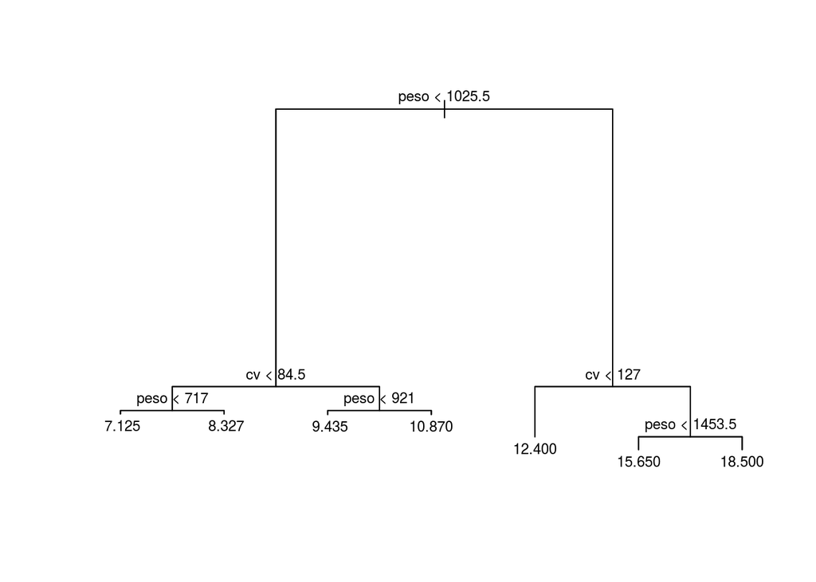

```r
t2 = tree(consumo ~ cv + peso,data=datos, control = tree.control(nobs=nrow(datos),mincut = 20,minsize = 40,mindev = 0.005))
plot(t2)
text(t2, cex=.75)
```

control:

- minsize: tamaño mínimo del nodo para que se divida en dos (por defecto, minsize = 10).
- mincut: si al dividir un nodo, uno de los nodos hijo tiene un tamaño inferior a éste, no se divide el nodo (por defecto, mincut = 5). Ojo, mincut ha de ser menor que minsize/2.
- mindev: para que un nodo se divida, la deviance del nodo tiene que ser mayor que mindev por la deviance del nodo raiz.

```r
print(t2)
```

```
## node), split, n, deviance, yval
##       * denotes terminal node
##
##  1) root 391 5911.00 11.230
##    2) peso < 1025.5 232  839.70  8.711
##      4) cv < 84.5 124  212.90  7.629
##        8) peso < 717 72   83.88  7.125 *
##        9) peso > 717 52   85.44  8.327 *
##      5) cv > 84.5 108  314.80  9.954
##       10) peso < 921 69  151.00  9.435 *
##       11) peso > 921 39  112.40 10.870 *
##    3) peso > 1025.5 159 1458.00 14.900
##      6) cv < 127 63  235.10 12.400 *
##      7) cv > 127 96  569.80 16.540
##       14) peso < 1453.5 66  243.00 15.650 *
##       15) peso > 1453.5 30  159.50 18.500 *
```

## Training set *vs* Validation set

Dividimos los datos en dos partes, una para entrenar el modelo y otra para calcular el error de predicción con datos diferentes de los utilizados para entrenar:

```r
set.seed(321)
ndat = nrow(datos)
train = sample(1:ndat,ndat/2) # la mitad de los datos para entranamiento
datos_t = datos[train,] # trainning set
datos_v = datos[-train,] # validation set
```

Entrenamiento del modelo

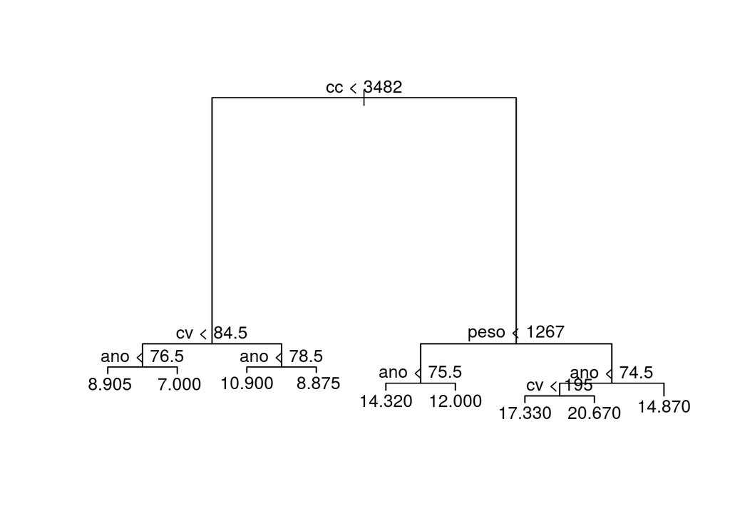

```r
t3 <- tree(consumo ~ ., data = datos_t)
plot(t3)
text(t3)
```

Error del modelo

```r
yt_p <- predict(t3, newdata = datos_t)
```

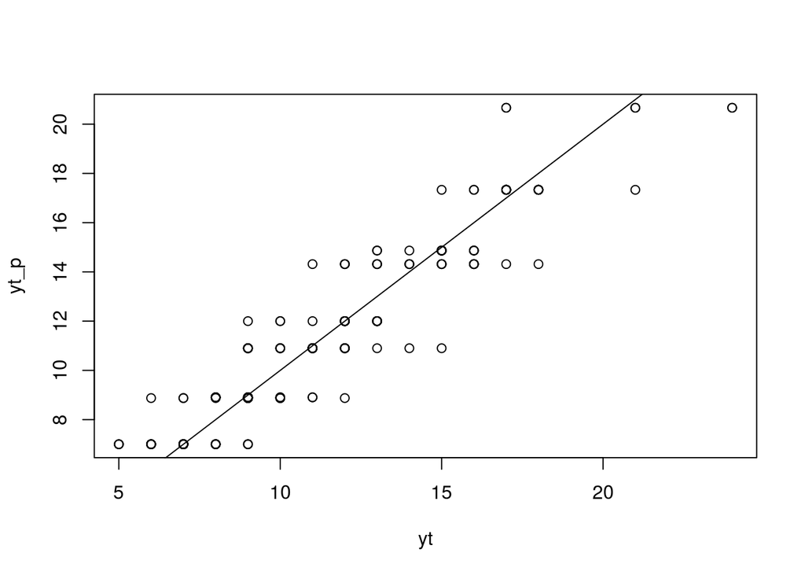

```r
yt = datos_t$consumo
plot(yt,yt_p)
abline(0,1) # como pintamos y vs yp, la relacion perfecta deberia ser una recta a 45º (m=1)
```

```r
( MSE_t = mean((yt-yt_p)^2) ) # error cuadratico medio en los datos de training
```

```
## [1] 1.703067
```

```r
# prediccion del consumo con los datos de validacion
yv_p = predict(t3, newdata = datos_v)

# error del validation set
yv = datos_v$consumo
(MSE_v = mean((yv-yv_p)^2))
```

```
## [1] 3.114328
```

El error es mucho mayor con los datos de validación!